# R Notebook

# Visualizations in R

### Popular graph packages:

- ggplot2
- Plotly
- Lattice
- RGL
- Dygraphs
- Leaflet
- Highcharter
- Patchwork
- gganimate
- ggridges

### Benefits of ggplot2:

- Create different types of plots
- Customize the look and feel of plots
- Create high quality visuals
- Combine data manipulation and visualization

### Concepts in ggplot2:

- **Aesthetics** –> A visual property of an object in your plot (shape, color)
- **Geoms** —> The geometric object used to represent your data (lines, bars)
- **Facets** —> Let you display smaller groups, or subsets, of your data
- **Labels and annotation**s —> Let you Customize your plot

## Create graph basic

```r
install.packages("ggplot2")
```

```
Error in install.packages : Updating loaded packages
```

```r
install.packages("palmerpenguins")
```

```
Error in install.packages : Updating loaded packages
```

```r
library(ggplot2)
library(palmerpenguins)
```

```r
data(penguins)
```

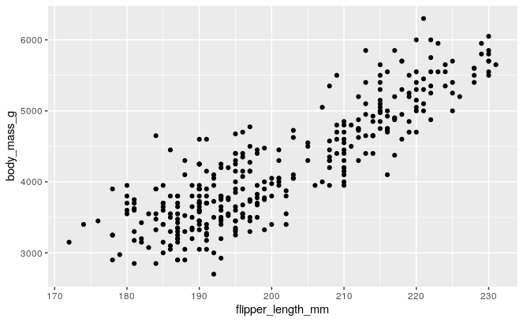

```r
ggplot(data = penguins) +
  geom_point(mapping = aes(x = flipper_length_mm, y = body_mass_g))
```

- geom_point() –> Scatterplots graph
- geom_bar() –> Bars graph

Each geom function in ggplot2 takes a **mapping argument**. This defines how variables in your dataset are mapped to visual properties. The mapping argument is always paired with the **aes() function**.

# Getting started with ggplot()

```r
library("palmerpenguins")
library("ggplot2")
```

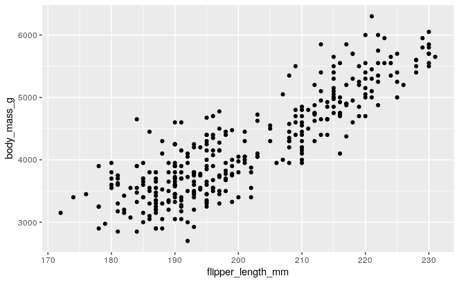

```r
ggplot(data = penguins) +
  geom_point(mapping=aes(x=flipper_length_mm, y=body_mass_g))
```

```r
body <- na.omit(penguins$body_mass_g)
flipper <- na.omit(penguins$flipper_length_mm)

cor(flipper, body)
```

```
[1] 0.8712018
```

( + ) is used for add layer in the graph.

1. Start with the ggplot function and choose a dataset to work with
2. Add a geom_function to display your data
3. Map the variables you want to plot in the arguments of the aes() function

```r
# Help is very useful
?geom_bar
```

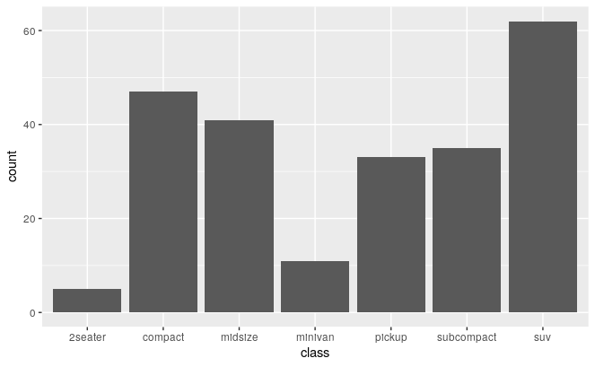

```r
# geom_bar is designed to make it easy to create bar charts that show
# counts (or sums of weights)
g <- ggplot(mpg, aes(class))
# Number of cars in each class:
g + geom_bar()
```

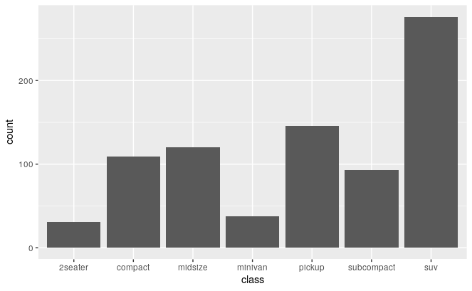

```r
# Total engine displacement of each class
g + geom_bar(aes(weight = displ))
```

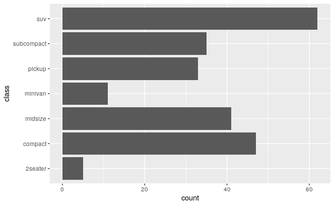

```r
# Map class to y instead to flip the orientation
ggplot(mpg) + geom_bar(aes(y = class))
```

# Enhancing visualizations in R

#### Colors

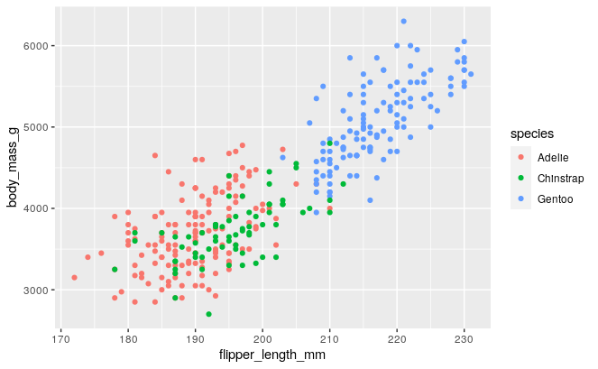

```r
ggplot(data = penguins) +
  geom_point(mapping=aes(x=flipper_length_mm, y=body_mass_g, color = species))
```

#### Shape

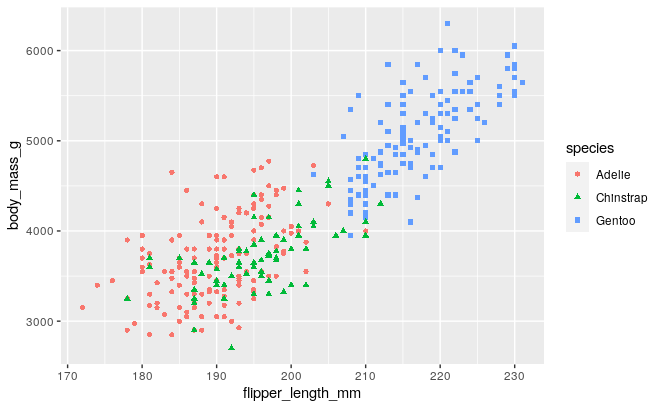

```r
ggplot(data = penguins) +
  geom_point(mapping=aes(x=flipper_length_mm, y=body_mass_g, color= species,
                         shape = species))
```

#### Size

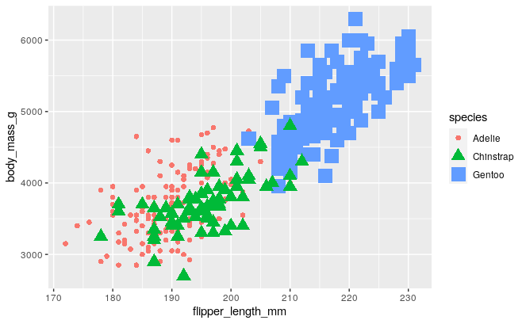

```r
ggplot(data = penguins) +
  geom_point(mapping=aes(x=flipper_length_mm, y=body_mass_g, color= species,
                         shape = species, size = species))
```